# 🎧 Mi vida en canciones

Más de una década de música, contada con datos

🕒 Fecha y hora de generación: 24-10-2026, 01:15 (hora de Chile)

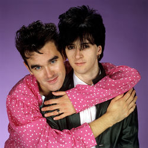

191.596 canciones escuchadas

Desde 2013 hasta hoy · 3.269 artistas · post-punk, metal y mucho rock chileno

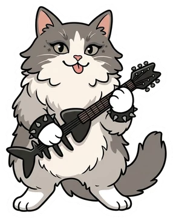

👋 **¡Hola!** Soy Joaquín, sociólogo y amante de los datos. Desde 2013 uso [Last.fm](https://www.last.fm/user/jgaldamesh), un servicio que registra automáticamente cada canción que escucho en Spotify u otras apps (a cada registro se le llama *scrobble*). Este reporte convierte esos 13 años de registros en una radiografía de mis gustos.

🖱️ **Cómo leerlo:** pasa el mouse (o toca, en el celular) sobre los gráficos para ver los valores, cambia de pestaña dentro de cada sección y ordena las tablas haciendo clic en sus columnas. El índice (a la izquierda en el computador) te lleva a cada parte. 📅 También puedes ver mi reporte del último mes y cómo está hecho.

🎵

191.596

canciones escuchadas

desde el 17-09-2013

⏱️

11.176

horas de música

≈ 466 días sin parar

🎤

3.269

artistas distintos

💿

31.466

canciones distintas

📅

40

canciones al día

en promedio

🔥

277 días

racha sin parar

15-07-2024 al 17-04-2025

## 🎸 Mi perfil musical

**NotaEn pocas palabras**

*Escrito el 24-10-2026, con los datos hasta esa fecha.*

**Guitarras, ruido y oscuridad.** Casi tres cuartos de lo que escucho cae en la dimensión *intensa* del modelo MUSIC (ver más abajo). El género que más pesa es el **post-punk** (14%), seguido de una familia completa de metal: heavy, black, sludge, thrash, death, stoner y doom. También hay mucho post-hardcore y asoma el hip-hop.

**Un viaje del metal al post-punk.** En 2013–2015 mandaban el metal y el hardcore (Godflesh, Black Sabbath, Amenra), con el punk de Attaque 77 de por medio. El post-punk pasó de nada en 2013 a su punto más alto en 2023 (22% de mis escuchas) y hoy ronda el 16%, de la mano de la ola británica e irlandesa: **IDLES** fue mi artista del año cuatro veces, y le siguen **Fontaines D.C.** y **Black Country, New Road**. En los últimos dos años se abrió hacia lo más melódico, con **La Brígida Orquesta** como artista de 2025.

**Muy local.** Una de cada cuatro escuchas de artistas con país identificado es de un artista **chileno**, y si sumo Argentina, más de un tercio es del Cono Sur. Mi artista número uno de todos los tiempos es **Tenemos Explosivos**, presente los 14 años del historial. Lo acompañan La Brígida Orquesta, Macha y el Bloque Depresivo, Fiskales Ad-Hok, Yajaira y Los Tres.

**Fiel y de nicho.** Hoy soy más de volver a lo conocido que de explorar: solo un 7% de mis escuchas del último año fue a artistas nuevos. El artista típico que escucho tiene unos 300 mil oyentes en Last.fm, lejos de los millones de un artista masivo. Entre las joyas escondidas, con menos de 10 mil oyentes, están Yajaira, Asamblea Internacional del Fuego y Agriculture.

**Música para trabajar.** El patrón es de oficina: escucho sobre todo de lunes a viernes entre las 9 y las 18 horas. Los fines de semana solo suman un 16% de las escuchas.

**Géneros**

Mis géneros

Proporción de escuchas según el género principal de cada artista (tags de Last.fm)

[interactive chart not shown]

**Países**

¿De dónde viene lo que escucho?

Escuchas de artistas con país identificado en sus etiquetas de Last.fm

EE.UU.

Interpol, Tom Waits

27%

Chile

Tenemos Explosivos, La Brigida Orquesta

24%

Reino Unido

IDLES, The Smiths

21%

Argentina

Charly García, Sumo

9%

Suecia

Viagra Boys, Entombed

3%

Irlanda

Fontaines D.C., my bloody valentine

3%

España

La Polla Records, C. Tangana

2%

Bélgica

Amenra, Stromae

2%

Australia

Nick Cave & the Bad Seeds, AC/DC

2%

Noruega

Ulver, Darkthrone

1%

Dinamarca

Volbeat, King Diamond

1%

Canadá

Voivod, Home Front

1%

## 🧭 Mi personalidad de oyente

Inspirado en las [personalidades de oyente de Spotify Wrapped](https://www.aol.com/16-personality-types-spotify-wrapped-195652285.html), que describen cómo escucha cada persona con pares de rasgos: si explora o vuelve a lo conocido, si es leal a pocos artistas o varía, si repite canciones y si escucha lo masivo o lo de nicho. Cada pestaña es un período: los **últimos 12 meses** y cada año desde que uso Last.fm. La pestaña **Evolución** muestra cómo fui cambiando. Los umbrales que separan un polo del otro son una decisión propia y se muestran bajo cada eje.

**Últimos 12 meses**

[figure not shown]

**2026**

[figure not shown]

**2025**

[figure not shown]

**2024**

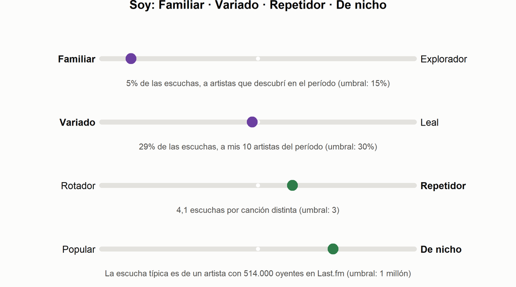

**2023**

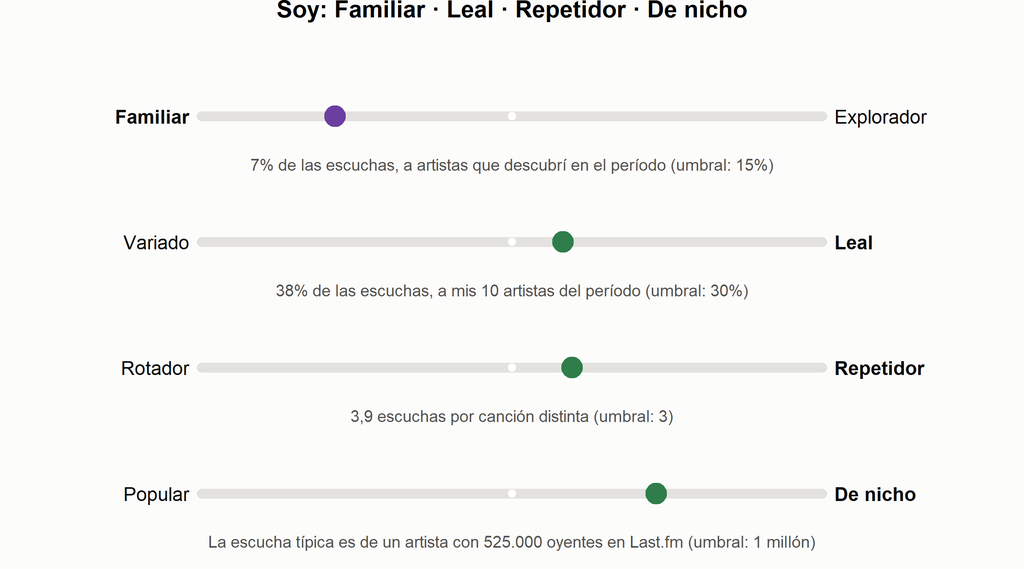

**2022**

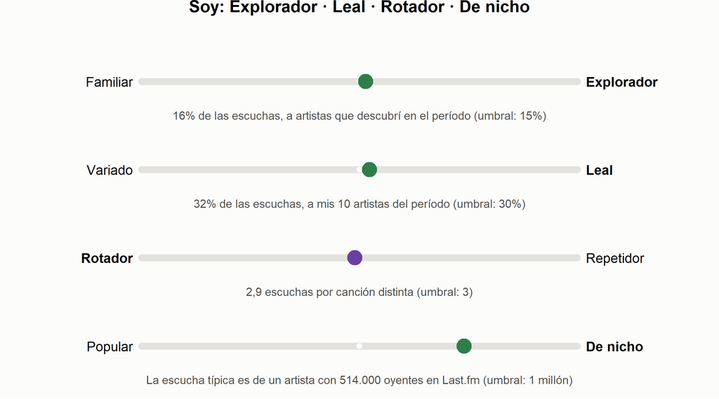

**2021**

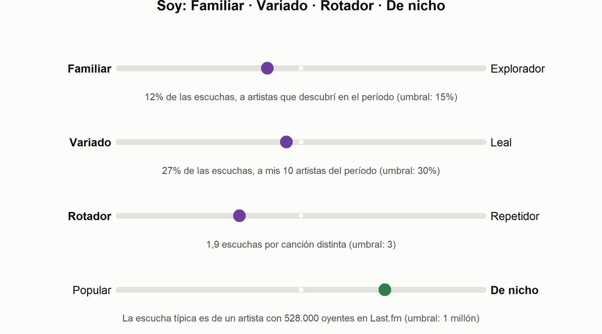

**2020**

[figure not shown]

**2019**

[figure not shown]

**2018**

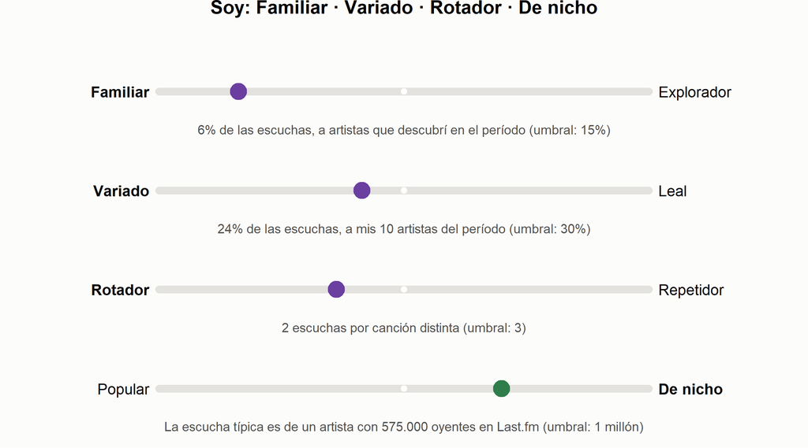

**2017**

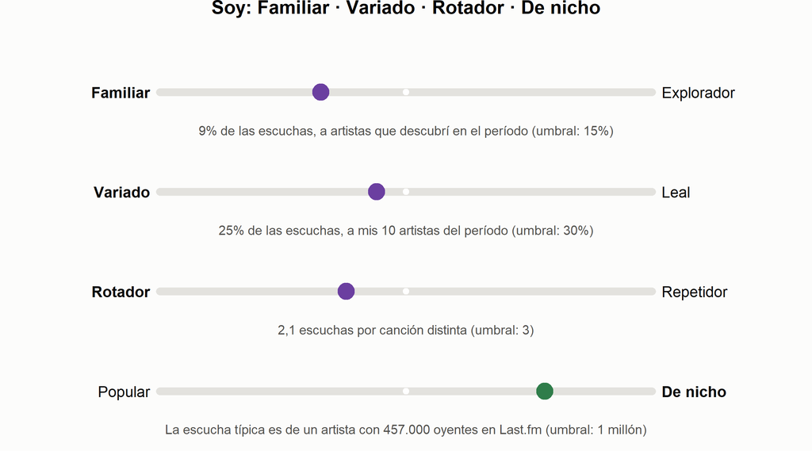

**2016**

[figure not shown]

**2015**

[figure not shown]

**2014**

[figure not shown]

**2013**

*Primer año del historial: todos los artistas cuentan como nuevos.*

[figure not shown]

**Evolución**

Mi personalidad de oyente, año a año

En verde, el polo de la derecha de cada eje; en morado, el de la izquierda

↕ Haz clic en el nombre de una columna para ordenar

| Año | Exploración | Lealtad | Repetición | Popularidad |
| --- | --- | --- | --- | --- |
| 2026 | Familiar\|7% de las escuchas, a artistas que descubrí en el período (umbral: 15%) | Leal\|33% de las escuchas, a mis 10 artistas del período (umbral: 30%) | Repetidor\|3,4 escuchas por canción distinta (umbral: 3) | De nicho\|La escucha típica es de un artista con 293.000 oyentes en Last.fm (umbral: 1 millón) |
| 2025 | Familiar\|10% de las escuchas, a artistas que descubrí en el período (umbral: 15%) | Leal\|33% de las escuchas, a mis 10 artistas del período (umbral: 30%) | Repetidor\|3,7 escuchas por canción distinta (umbral: 3) | De nicho\|La escucha típica es de un artista con 345.000 oyentes en Last.fm (umbral: 1 millón) |
| 2024 | Familiar\|5% de las escuchas, a artistas que descubrí en el período (umbral: 15%) | Variado\|29% de las escuchas, a mis 10 artistas del período (umbral: 30%) | Repetidor\|4,1 escuchas por canción distinta (umbral: 3) | De nicho\|La escucha típica es de un artista con 514.000 oyentes en Last.fm (umbral: 1 millón) |
| 2023 | Familiar\|7% de las escuchas, a artistas que descubrí en el período (umbral: 15%) | Leal\|38% de las escuchas, a mis 10 artistas del período (umbral: 30%) | Repetidor\|3,9 escuchas por canción distinta (umbral: 3) | De nicho\|La escucha típica es de un artista con 525.000 oyentes en Last.fm (umbral: 1 millón) |
| 2022 | Explorador\|16% de las escuchas, a artistas que descubrí en el período (umbral: 15%) | Leal\|32% de las escuchas, a mis 10 artistas del período (umbral: 30%) | Rotador\|2,9 escuchas por canción distinta (umbral: 3) | De nicho\|La escucha típica es de un artista con 514.000 oyentes en Last.fm (umbral: 1 millón) |
| 2021 | Familiar\|12% de las escuchas, a artistas que descubrí en el período (umbral: 15%) | Variado\|27% de las escuchas, a mis 10 artistas del período (umbral: 30%) | Rotador\|1,9 escuchas por canción distinta (umbral: 3) | De nicho\|La escucha típica es de un artista con 528.000 oyentes en Last.fm (umbral: 1 millón) |
| 2020 | Explorador\|16% de las escuchas, a artistas que descubrí en el período (umbral: 15%) | Variado\|24% de las escuchas, a mis 10 artistas del período (umbral: 30%) | Rotador\|2,1 escuchas por canción distinta (umbral: 3) | De nicho\|La escucha típica es de un artista con 512.000 oyentes en Last.fm (umbral: 1 millón) |
| 2019 | Familiar\|14% de las escuchas, a artistas que descubrí en el período (umbral: 15%) | Leal\|31% de las escuchas, a mis 10 artistas del período (umbral: 30%) | Repetidor\|3,3 escuchas por canción distinta (umbral: 3) | De nicho\|La escucha típica es de un artista con 505.000 oyentes en Last.fm (umbral: 1 millón) |
| 2018 | Familiar\|6% de las escuchas, a artistas que descubrí en el período (umbral: 15%) | Variado\|24% de las escuchas, a mis 10 artistas del período (umbral: 30%) | Rotador\|2 escuchas por canción distinta (umbral: 3) | De nicho\|La escucha típica es de un artista con 575.000 oyentes en Last.fm (umbral: 1 millón) |
| 2017 | Familiar\|9% de las escuchas, a artistas que descubrí en el período (umbral: 15%) | Variado\|25% de las escuchas, a mis 10 artistas del período (umbral: 30%) | Rotador\|2,1 escuchas por canción distinta (umbral: 3) | De nicho\|La escucha típica es de un artista con 457.000 oyentes en Last.fm (umbral: 1 millón) |

[output cut: 4 more lines]

### ¿Qué tan de nicho es lo que escucho?

**Popularidad de mis artistas**

Clasifiqué a todos mis artistas en cuatro niveles según cuántos oyentes tienen en Last.fm, la red de más de 60 millones de usuarios donde registro mis escuchas.

¿Cuánto escucho de cada nivel de popularidad?

Proporción de mis escuchas según los oyentes del artista en Last.fm

[interactive chart not shown]

↕ Haz clic en el nombre de una columna para ordenar

| Nivel | Artistas | % de mis escuchas | Mis favoritos en este nivel |
| --- | --- | --- | --- |
| 🕳️ Underground (menos de 10 mil) | 422 | 0.0515250840309819 | Yajaira, Asamblea Internacional del Fuego, Agriculture, Publicist UK |
| 🕯️ De culto (10 mil a 100 mil) | 1006 | 0.204665024322011 | Tenemos Explosivos, La Brigida Orquesta, Macha y el Bloque Depresivo, Fiskales Ad-Hok |
| 🎙️ Conocido (100 mil a 1 millón) | 1284 | 0.421151798576171 | IDLES, Black Country, New Road, Deafheaven, Amenra |
| 🌍 Masivo (más de 1 millón) | 557 | 0.322658093070837 | Fontaines D.C., Interpol, The Smiths, Nick Cave & the Bad Seeds |

¿Me he vuelto más o menos de nicho?

Proporción de cada nivel de popularidad en las escuchas de cada año

[interactive chart not shown]

**¿Qué me dice?** El grueso de lo que escucho está en artistas **conocidos pero no masivos**: el nivel de 100 mil a 1 millón de oyentes concentra el 42% de mis escuchas, y los masivos solo el 32%. Escucho artistas con escena propia, lejos del *mainstream* pero no secretos. En el tiempo, lo masivo pasó del 31% en 2013 al 27% en 2026, y lo underground y de culto, del 18% al 38%. Gran parte de mi nicho son **bandas chilenas**, que tienen pocos oyentes a escala global aunque sean importantes en la escena local.

**Joyas escondidas**

Joyas escondidas

Los artistas con menos oyentes en Last.fm entre los que he escuchado al menos 100 veces

↕ Haz clic en el nombre de una columna para ordenar

| Artista | Mis escuchas | Oyentes en Last.fm |
| --- | --- | --- |
| La Bestia de Gevaudan | 372 | 1286 |
| Baikonur | 174 | 1667 |
| Sick Porky | 131 | 2020 |
| Hielo Negro | 192 | 3488 |
| Los Espiritus | 515 | 3615 |
| Agriculture | 1188 | 3745 |
| Hermética | 284 | 4989 |
| Publicist UK | 848 | 5215 |
| True Body | 299 | 5219 |
| Electrodomésticos | 105 | 6406 |

[output cut: 2 more lines]

### Mis gustos según el modelo MUSIC

La psicología de la música resume las preferencias musicales en cinco dimensiones: el [modelo MUSIC de Rentfrow y colaboradores](https://www.gsb.stanford.edu/index%2Ephp/node/428616). Su nombre son las iniciales de cada una en inglés. Aquí se aproximan asignando las etiquetas de cada artista a una dimensión; la pestaña **¿Qué es cada dimensión?** explica cada una.

**Mi perfil MUSIC**

Mi perfil MUSIC

Peso de cada dimensión en mis escuchas

[interactive chart not shown]

**¿Qué es cada dimensión?**

Las cinco dimensiones del modelo MUSIC

Basado en Rentfrow, Goldberg y Levitin (2011); los ejemplos son los géneros usados aquí para cada dimensión

↕ Haz clic en el nombre de una columna para ordenar

|  | Dimensión | Qué es | Géneros de ejemplo |
| --- | --- | --- | --- |
| M | Suave (Mellow) | Música tranquila, lenta y relajante, de emociones apacibles o románticas. | Soft rock, R&B lento, chillout, dream pop, ambient, baladas |
| U | De raíz (Unpretentious) | Música sencilla, directa y tradicional, ligada a lo cotidiano y a las raíces. | Country, folk, trova, folclore, cumbia, rock and roll clásico |
| S | Sofisticada (Sophisticated) | Música compleja e intelectual, que pide atención: armonías y estructuras elaboradas. | Jazz, clásica, blues, post-rock, rock progresivo, experimental |
| I | Intensa (Intense) | Música fuerte, enérgica y distorsionada, de emociones intensas. | Rock, metal, punk, hardcore, post-punk, noise, grunge |
| C | Contemporánea (Contemporary) | Música rítmica y bailable, de producción actual y popular. | Hip-hop, electrónica, pop, reggaetón, funk, dance |

## 📈 La línea de tiempo

**Por mes**

Escuchas por mes

En verde, el mes récord: 01-2024 (2.569 escuchas)

[interactive chart not shown]

**Calendario**

El calendario de los últimos años

Pasa el mouse por un día para ver sus escuchas

[interactive chart not shown]

## ⏰ Mi ritmo

**Hora y día**

¿A qué hora escucho música?

Todas las escuchas, por hora y día de la semana

[interactive chart not shown]

**Franjas y sesiones**

**Teoría.** La socióloga Tia DeNora, en *Music in Everyday Life* (2000), describe la música como una **“tecnología del yo”**: la usamos para regular el ánimo, la energía y la concentración en la vida cotidiana. Mi patrón de horario de oficina calza con esa idea: la música como compañía para trabajar.

Escucho 43% de mi música en la tarde, 19% en la noche, 29% en la mañana y 9% de madrugada. Los fines de semana concentran el 16% de las escuchas (si fuera parejo, sería un 29%).

Si una sesión termina tras 30 minutos sin música, he tenido 14.023 sesiones. La mediana es de 9 canciones. Mi maratón más larga fue el 27-03-2026: **126 canciones seguidas** durante 8.3 horas.

## 🌟 Mis artistas

**Mis 12 artistas**

Tenemos Explosivos

6.453 escuchas

IDLES

4.024 escuchas

Black Country, New Road

3.903 escuchas

Deafheaven

3.809 escuchas

Fontaines D.C.

3.305 escuchas

Interpol

3.268 escuchas

Amenra

2.718 escuchas

La Brigida Orquesta

2.474 escuchas

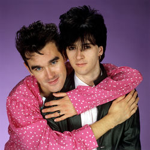

The Smiths

2.471 escuchas

Charly García

2.228 escuchas

Nick Cave & the Bad Seeds

2.121 escuchas

Macha y el Bloque Depresivo

2.040 escuchas

**Mis 12 discos**

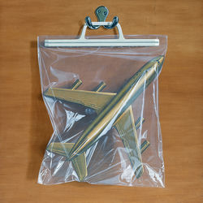

Ants From Up There

Black Country, New Road · 2.351

Cortacalles

Tenemos Explosivos · 2.266

[figure not shown]

Romance

Fontaines D.C. · 1.762

[figure not shown]

Derrumbe y Celebracion

Tenemos Explosivos · 1.620

[figure not shown]

La Virgen de los Mataderos

Tenemos Explosivos · 1.503

[figure not shown]

Alive

Amenra · 1.333

[figure not shown]

Portamento

The Drums · 1.279

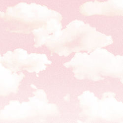

GLOW ON

Turnstile · 1.233

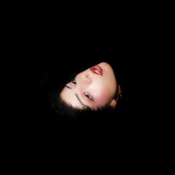

La Brea

Hesse Kassel · 1.085

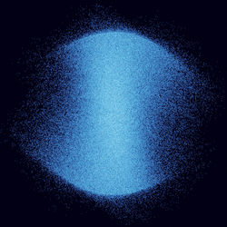

Infinite Granite

Deafheaven · 997

Macha y el Bloque Depresivo

Macha y el Bloque Depresivo · 996

[figure not shown]

Victoria

Tenemos Explosivos · 953

**Top 25**

Los 25 artistas que más he escuchado

[interactive chart not shown]

**Ranking año a año**

**Teoría.** El **pico de reminiscencia** (*reminiscence bump*) es la tendencia a recordar con más cariño la música que escuchamos entre los 10 y los 30 años (Krumhansl y Zupnick, 2013). Los artistas que aparecen en el ranking todos los años, como Tenemos Explosivos o Black Sabbath, son candidatos a ser esa banda sonora fundacional.

El ranking de mis 15 favoritos, año a año

Posición de cada artista entre todo lo que escuché ese año (más oscuro = más arriba)

[interactive chart not shown]

**Artista y canción del año**

Artista y canción de cada año

↕ Haz clic en el nombre de una columna para ordenar

| Año | Escuchas | Artista del año |  | Canción del año |  |
| --- | --- | --- | --- | --- | --- |
| 2013 | 2862 | Bad Religion | 135 | You — Bad Religion | 9 |
| 2014 | 9586 | Godflesh | 322 | Dream House — Deafheaven | 46 |
| 2015 | 11440 | Attaque 77 | 385 | Rey de Creta — Tenemos Explosivos | 35 |
| 2016 | 6050 | Tom Waits | 297 | Blood Relative — Publicist UK | 25 |
| 2017 | 12687 | Amenra | 677 | Wear My Crown — Amenra | 66 |
| 2018 | 9278 | Fugazi | 275 | Long Division — Fugazi | 21 |
| 2019 | 21350 | Nick Cave & the Bad Seeds | 1046 | Het dorp — Amenra | 76 |
| 2020 | 9329 | IDLES | 637 | Mr. Motivator — IDLES | 54 |
| 2021 | 7007 | IDLES | 406 | The Beachland Ballroom — IDLES | 38 |
| 2022 | 14648 | IDLES | 950 | Great Mass of Color — Deafheaven | 60 |

[output cut: 4 more lines]

## 🔍 Explorar o volver a lo conocido

**Diversidad por año**

Diversidad por año

% de escuchas que fueron a artistas descubiertos ese año, y a los 10 más escuchados del año

↕ Haz clic en el nombre de una columna para ordenar

| Año | Escuchas | Artistas | Artistas nuevos | % a nuevos | % a top 10 |
| --- | --- | --- | --- | --- | --- |
| 2013 | 2862 | 106 | 106 | 1 | 0.335779175401817 |
| 2014 | 9586 | 228 | 137 | 0.31264343834759 | 0.248800333820154 |
| 2015 | 11440 | 338 | 179 | 0.213111888111888 | 0.264335664335664 |
| 2016 | 6050 | 329 | 136 | 0.151404958677686 | 0.265289256198347 |
| 2017 | 12687 | 443 | 184 | 0.0929297706313549 | 0.254354851422716 |
| 2018 | 9278 | 386 | 157 | 0.0588488898469498 | 0.236796723431774 |
| 2019 | 21350 | 663 | 360 | 0.139484777517564 | 0.31480093676815 |
| 2020 | 9329 | 638 | 336 | 0.16100332297138 | 0.243648836960017 |
| 2021 | 7007 | 616 | 267 | 0.116169544740973 | 0.268873983159697 |
| 2022 | 14648 | 908 | 461 | 0.156198798470781 | 0.319838885854724 |

[output cut: 4 more lines]

**¿Soy omnívoro?**

**Teoría.** Bourdieu (1979) veía el gusto como marca de clase: las élites consumían “alta cultura” y despreciaban lo popular. Richard Peterson (1992; Peterson y Kern, 1996) mostró que eso cambió: el nuevo signo de distinción es ser **omnívoro**, es decir, disfrutar de muchos géneros, cultos y populares a la vez.

**¿Cómo se mide?** No basta con contar cuántos géneros escuché: si en un año escuché 50 géneros, pero el 95% fue metal, no soy muy omnívoro. Por eso uso el **número efectivo de géneros**, una medida de diversidad que viene de la ecología y la teoría de la información (es el exponencial de la entropía de Shannon). Responde a la pregunta: *¿a cuántos géneros, igual de escuchados, equivale mi mezcla real?*

- Si escuchara **un solo género**, el índice sería **1**.
- Si repartiera mis escuchas **en partes iguales entre 30 géneros**, sería **30**.
- Si escuchara 30 géneros pero casi todo fuera uno solo, sería cercano a **1**.

Mientras más alto, más **repartido** está mi gusto entre géneros.

Mi índice de omnivorismo

Número efectivo de géneros por año: más alto = gustos más repartidos entre géneros

[interactive chart not shown]

**Géneros en el tiempo**

Cómo han cambiado mis géneros

% de las escuchas de cada año, para mis 12 géneros principales (número = % si es 3% o más)

[interactive chart not shown]

## 🌦️ Momentos

**¿Cuándo escucho a quién?**

Artistas con al menos 300 escuchas cuya música se concentra en ciertos momentos más que mi promedio.

De madrugada (0 a 6 h)

Mi promedio: 9%

↕ Haz clic en el nombre de una columna para ordenar

| Artista | % de sus escuchas | vs. promedio |
| --- | --- | --- |
| Bohren & der Club of Gore | 0.489891135303266 | 5.32123033956372 |
| Cathedral | 0.346560846560847 | 3.7643671385947 |
| Down | 0.302608695652174 | 3.28695593016463 |
| Goldmund | 0.279022403258656 | 3.0307600416546 |
| Misfits | 0.271428571428571 | 2.94827533144898 |
| Saint Vitus | 0.261538461538462 | 2.84084829508039 |
| Bad Religion | 0.252873563218391 | 2.74672958888774 |
| Dead Kennedys | 0.238636363636364 | 2.59208417298445 |

De fin de semana

Mi promedio: 16%

↕ Haz clic en el nombre de una columna para ordenar

| Artista | % de sus escuchas | vs. promedio |
| --- | --- | --- |
| Brujeria | 0.347417840375587 | 2.20337201405498 |
| Mon Laferte | 0.31239092495637 | 1.98122646997486 |
| Saint Vitus | 0.311538461538462 | 1.97582002902758 |
| In Solitude | 0.30561797752809 | 1.93827150024733 |
| Anthrax | 0.304733727810651 | 1.93266346619032 |
| King Diamond | 0.291021671826625 | 1.84569970987402 |
| Bad Religion | 0.289272030651341 | 1.83460324345165 |
| Pink Floyd | 0.288819875776398 | 1.83173561467245 |

**Mis estaciones**

¿Qué género sube en cada estación?

Peso del género en la estación comparado con su promedio del año (estaciones del hemisferio sur)

[interactive chart not shown]

**Pandemia**

Mi música en tres tiempos

Pandemia = estado de catástrofe en Chile (18-03-2020 al 30-09-2021)

↕ Haz clic en el nombre de una columna para ordenar

| Período | Escuchas por día | % chilenos | Mis 5 artistas |
| --- | --- | --- | --- |
| Antes | 31.7674810446504 | 0.161353127281577 | Amenra, Tenemos Explosivos, Black Sabbath, Tom Waits, Nick Cave & the Bad Seeds |
| Pandemia | 21.1120996441281 | 0.139800995024876 | IDLES, Viagra Boys, Interpol, Napalm Death, Mark Lanegan |
| Después | 56.4169821525149 | 0.31620469334971 | Tenemos Explosivos, Black Country, New Road, Fontaines D.C., Deafheaven, IDLES |

## 🎭 Mi ánimo musical

Un análisis de sentimiento a partir de las **etiquetas de ánimo** que la comunidad de Last.fm pone a cada artista (“melancholic”, “aggressive”, “happy”, “chill”, “dark”…). Cada etiqueta se ubica en el [modelo circunflejo del afecto de Russell](https://doi.org/10.1037/h0077714): **valencia** (triste ↔︎ alegre) y **energía** (calma ↔︎ intensidad). Cada artista recibe el promedio de sus etiquetas, ponderado por su peso, y cada período el promedio de lo que escuché. Mide el ánimo de la *música*, no el mío, aunque algo dice.

Las etiquetas de ánimo cubren el 77% de mis escuchas.

**Año a año**

Mi ánimo musical, año a año

Sobre cero: más alegre / más intensa. Bajo cero: más triste / más calma (escala de -1 a 1)

[interactive chart not shown]

**Según la hora**

**¿Qué son valencia y energía?** Son las dos dimensiones con que la psicología ubica cualquier emoción (Russell, 1980):

- 🙂 **Valencia**: qué tan **positiva o negativa** se siente la música. Va de −1 (triste, oscura, melancólica; p. ej. el doom de Black Sabbath) a +1 (alegre, luminosa; p. ej. la cumbia de Chico Trujillo).
- ⚡ **Energía**: qué tan **activadora o calmada** es. Va de −1 (tranquila, suave; p. ej. ambient o folk) a +1 (intensa, rápida, fuerte; p. ej. hardcore o thrash).

Combinadas dan cuatro estados: **eufórica** (alegre y enérgica), **serena** (alegre y calma), **melancólica** (triste y calma) y **tensa** (triste y enérgica). Se calculan a partir de las etiquetas de ánimo que los usuarios de Last.fm ponen a cada artista.

¿Me pongo más oscuro de noche?

Valencia (bajo cero = más triste) y energía (sobre cero = más intensa) según la hora del día

[interactive chart not shown]

**Días extremos**

**¿Cómo se leen?** Para cada día con al menos 40 escuchas promedié la **valencia** de todo lo que escuché ese día (de −1, muy triste u oscuro, a +1, muy alegre). Los **días más oscuros** son los cinco con el promedio más bajo: jornadas casi enteras de música sombría. Los **más luminosos**, los cinco con el promedio más alto. El “artista del día” es el que más sonó esa jornada y suele explicar el resultado.

Mis días más oscuros y más luminosos

Valencia promedio del día (−1 = muy triste, +1 = muy alegre), en días con al menos 40 escuchas

↕ Haz clic en el nombre de una columna para ordenar

|  | Día | Artista del día | Valencia | Escuchas |
| --- | --- | --- | --- | --- |
| Mis días más oscuros | 14-08-2015 | Cathedral | -0.69880174291939 | 63 |
| Mis días más oscuros | 11-08-2014 | Black Sabbath | -0.69383541295306 | 66 |
| Mis días más oscuros | 05-06-2015 | Black Sabbath | -0.678306283143179 | 49 |
| Mis días más oscuros | 13-03-2017 | Spiritual Beggars | -0.676312521639341 | 44 |
| Mis días más oscuros | 23-11-2013 | Witchfinder General | -0.674740212865968 | 64 |
| Mis días más luminosos | 20-12-2019 | La Floripondio | 0.449265035105594 | 60 |
| Mis días más luminosos | 09-01-2015 | Chico Trujillo | 0.441254768561237 | 82 |
| Mis días más luminosos | 06-02-2015 | Chico Trujillo | 0.388386745402388 | 83 |
| Mis días más luminosos | 09-04-2022 | Billie Eilish | 0.366910147546185 | 42 |
| Mis días más luminosos | 06-11-2022 | Chico Trujillo | 0.323988296075747 | 47 |